# NIDS-CRAM 2020 Wave 1 National Income Dynamics Study-Coronavirus Rapid Mobile Survey The effect of COVID-19 on the labour and welfare of South Africans

## Group Members

Dino Anastasopoulos: 1900661  
Brenton Budler: 1827655  
Philani Mpofu: 1848751

# Table of Contents

## Executive Summary

### What is the purpose of this notebook?

- To perform EDA on the NIDS-CRAM Wave 1 dataset

### What is being modelled?

- The job security of people working in different occupations

### What are the main results

### Limitations

## Introduction

### Problem Context and Motivation

### Describe Questions

### Overview of Methodology

### Section Contents Overview

## Data Description

The coronavirus pandemic is the largest social and economic shock in our lifetime. The rapid spread of this virus around the world and the economic devastation it has left in its wake is unlike anything we have seen before, at least not in our lifetimes. The local and international landscape is constantly morphing and changing in unpredictable ways making policy formulation and implementation as hard as it can possibly be. Policies that are helpful and sensible today may be harmful and illogical tomorrow. Every month seems to yield new information and consequences that were unforeseen even six weeks before. Indeed, “There are decades where nothing happens, and there are weeks where decades happen” (Lenin).

It is within this context that we have convened a national consortium of 30 social science researchers from five South African universities to conduct the National Income Dynamics Study (NIDS) Coronavirus Rapid Mobile Survey (CRAM) over the course of May – December 2020. Because decision-making is only as good as the data on which it is based, the NIDS-CRAM project exists to collect, analyze and disseminate data on a broadly representative sample of South African individuals, and to report on their employment and welfare in light of the COVID-19 pandemic.

The Wave 1 employment questions ask respondents about the period February to April 2020, while many of the welfare questions (such as the presence and extent of hunger) reflect on the month of April as well as the ‘last seven days’. The month of April was an especially hard time in South Africa as the country was experiencing its most severe form of lockdown. Many South Africans income and employment was severely affected, and government relief efforts began in earnest in May (with the top up to existing government grants) and in June (with the progressive roll-out of the Special COVID-19 Social Relief of Distress Grant. We believe that the results of the NIDS-CRAM Wave 1 study included here are a helpful baseline from which to compare changes over time, and hopefully shed light on who is being affected, how they are being affected, and how might government and civil society respond to this unfolding crisis. The aim of this synthesis report is to present an overview of the high-level findings from the NIDSCRAM Working Paper Series which is made up of 11 papers. All of these papers use the NIDSCRAM Wave 1 data as their primary source and report on various aspects related to employment, poverty, hunger, grants, migration and adherence to COVID-19 prevention strategies. All papers have undergone peer-review. The papers and the data on which they are based are all freely available for anyone to download and use.

### Origin

When planning our approach of the project, we knew we wanted to focus on COVID-19's effect on the labour and welfare of South Africa but we weren't sure if we wanted to treat it as a cross-sectional study of the initial impact (only focusing on data from the first wave) or a longitudal study (focusing on data from all three waves). This initial Exploratory Data Analysis incorporates so that we could see which appraoch would be more feasible and would allow us to form the best inferences about the data.

The "Waves" referenced in the notebook and in the study indicate different phases at which the survey was conducted and do not coincide with the waves of COVID19 that South Africa experienced.

### Contents (Who, What, Where)

### Date Collected (When)

### Collection Method (How)

- Telephonically

### Dataset Size (Rows and Columns)

The dataset consists of 7073 records (rows) and 170 variables (columns)

### Date Downloaded

This data was downloaded from https://www.datafirst.uct.ac.za/dataportal/index.php/catalog/817 on the 5th of March 2021.

### Validations

### Aspects of Data Quality

- Validity: Does the data conform to a standard format?
- Accuracy: Does the data agree with reality or with a trusted external source?
- Completeness: Are all records present?
- Consistency: Is data in a field (down a column) or for an instance (across a row) in logical agreement?
- Uniformity: Are the same units used across a given field?

### Ability to Answer Question

## Data Wrangling & Exploratory Analyses

WRANGLING

Tidyness of Data (4)

Techniques: Joins, removing duplicates, cleaning variables, changing types, aggregations (4)

Sense checks after cleaning (raw vs cleaned) (2)

EXPLORATORY ANALYSIS

Choice of Initial Visualisations and Statistics (3)

Appropriate Measures (2)

Relevance to Questions (3)

Consideration of Accuracy (2)

### Imports

```python
import numpy as np
import pandas as pd
import matplotlib.pyplot as plt
import seaborn as sns
import matplotlib.cm as cm
from matplotlib.colors import Normalize
```

### Global Functions

```python
# Put ALL functions here
def replace_errors(x):
    if x == "Other" or x == "Don't know" or x == "Refused" or x=='Missing' or x== "Don't Know" or x=="Donât know":
        return np.NaN
    return x

def replace_all_missing(df):

    junk_terms = ["Don't know",
                  "Refused",
                  "Missing",
                  "Don't Know",
                  "Donât know"]

    df.replace(junk_terms, np.NaN, inplace=True)


    return df
```

### Read in data

```python
raw_data = pd.read_csv('Wave1.csv')
display(raw_data.head())

raw_data_nans = raw_data.apply(replace_all_missing)
```

|  | pid | w1_nc_outcome | w1_nc_intrv_c | w1_nc_intrv_d | w1_nc_intrv_m | w1_nc_intrv_y | w1_nc_duration | w1_nc_dob_m | w1_nc_dob_y | w1_nc_gen | ... | w1_nc_intlng2 | w1_nc_intlng3 | w1_nc_intlng4 | w1_nc_intlng5 | w1_nc_intlng6 | w1_nc_intlng7 | w1_nc_intlng8 | w1_nc_intlng9 | w1_nc_intlng10 | w1_nc_intlng11 |
| --- | --- | --- | --- | --- | --- | --- | --- | --- | --- | --- | --- | --- | --- | --- | --- | --- | --- | --- | --- | --- | --- |
| 0 | 301013 | Successfully Interviewed | 610 | 15th | June | 2020 | 15.95 | June | 1981.0 | Man | ... | NaN | NaN | NaN | NaN | NaN | NaN | NaN | NaN | NaN | NaN |
| 1 | 301058 | Successfully Interviewed | 611 | 25th | June | 2020 | 22.03 | January | 1948.0 | Woman | ... | NaN | NaN | NaN | NaN | NaN | NaN | NaN | NaN | NaN | NaN |
| 2 | 301059 | Successfully Interviewed | 604 | 20th | June | 2020 | 12.75 | July | 1990.0 | Woman | ... | NaN | NaN | NaN | NaN | NaN | NaN | NaN | NaN | NaN | NaN |
| 3 | 301062 | Successfully Interviewed | 640 | 25th | June | 2020 | 22.33 | June | 1972.0 | Woman | ... | English | NaN | NaN | NaN | NaN | NaN | NaN | NaN | NaN | NaN |
| 4 | 301067 | Successfully Interviewed | 609 | 15th | May | 2020 | 15.2 | July | 1971.0 | Woman | ... | NaN | NaN | NaN | NaN | NaN | NaN | NaN | NaN | NaN | NaN |

5 rows × 170 columns

### Initial dtype cleaning

```python
raw_data_nans = raw_data_nans.astype({
    "w1_nc_dob_y": float
})
```

## Section 1 - Demographics

### Data Description

**Personal Information:**

- **age** - Participants age
- **gender** - Participants gender
- **race** - Participants race

**Educational Information:**

- **highest_grade** - Highest school grade completed/passed
- **tertiary_edu** - Whether or not they have successfully completed any tertiary education

**Geographical Information:**

- **province_before** - Which province they lived in before lockdown
- **province_during** - Which province they lived in during lockdown

### Data Ingestion and Cleaning

```python
demdf = pd.DataFrame()

#Personal Information
demdf['age'] = 2020 - raw_data_nans['w1_nc_dob_y']
demdf['gender'] = raw_data_nans['w1_nc_gen']
demdf['race']= raw_data_nans['w1_nc_popgrp']

#Educational Information
demdf['highest_grade'] = raw_data_nans['w1_nc_edschgrd']
demdf['tertiary_edu'] = raw_data_nans['w1_nc_edter']

#Geographical Information
demdf['province_before'] = raw_data_nans['w1_nc_lvbfprov']
demdf['province_during'] = raw_data_nans['w1_nc_lvdurprov']

# display(demdf.head())
# display(demdf.info())
```

```python
demdf['highest_grade'].replace({'Grade 12 (Std10 / Matric / Senior Certificate / Form 5)': 'Grade 12',
    'Grade 11 (Std. 9/ Form 4)': 'Grade 11',
    'Grade 10 (Std. 8/ Form 3)': 'Grade 10',
    'Grade 9 (Std. 7/ Form 2)':  'Grade 9',
    'Grade 8 (Std. 6/ Form 1)':  'Grade 8',
    'Grade 7 (Std. 5)':  'Grade 7',
    'Grade 6 (Std. 4)':  'Grade 6',
    'Grade 5 (Std. 3)':  'Grade 5',
    'Grade 4 (Std. 2)':  'Grade 4',
    'Grade 3 (Std. 1)':  'Grade 3',
    'Grade 2 (previously Sub B/ class 2)':  'Grade 2',
    'Grade 1 (previously Sub A/ class 1)': 'Grade 1',
    'Grade R/0': 'Grade 0',
    'N1 (NATED)/ NTC 1': 'NTC 1',
    'N2 (NATED)/ NTC 2' : 'NTC 2',
    'N3 (NATED)/ NTC 3': 'NTC 3',
    'No Schooling': 'None',
    'National Certificate Vocational 2 (NCV 2)': 'NCV 2',
    'National Certificate Vocational 3 (NCV 3)': 'NCV 3',
    'National Certificate Vocational 4 (NCV 4)': 'NCV 4'}, inplace=True)

# demdf['highest_grade'].unique()
```

### Exploratory Data Analysis

Below, we will compare the sample to the findings from the 2019 mid-year population estimates in order to validate/critique the representation accuracy of demographics distribution of the sample in our dataset.  
This data can be found at (https://www.statssa.gov.za/publications/P0302/P03022019.pdf)

#### *Personal Information*

##### **Age**

Since the survey was about the National Income Dynamics, the people interviewed were in the range of (18, 102) and an average age of 40.37 which makes up the labour force/working age.

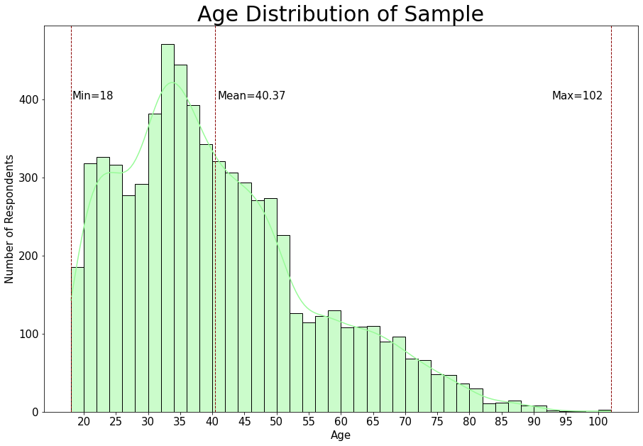

```python
min_age = int(demdf['age'].min())
max_age = int(demdf['age'].max())
plt.figure(figsize=(15,10))

sns.histplot(demdf['age'], bins=int((max_age-min_age)/2), color='palegreen', kde =True)

plt.title('Age Distribution of Sample',fontsize= 30)

plt.xlabel('Age',fontsize=15)
plt.ylabel('Number of Respondents',fontsize=15)
plt.xticks([20,25,30,35,40,45,50,55,60,65,70,75,80,85,90,95,100],fontsize=15)
plt.yticks(rotation='horizontal',fontsize=15)

plt.axvline(demdf['age'].mean(), color='darkred', linestyle='dashed', linewidth=1)
plt.text(demdf['age'].mean()*1.01, 400, 'Mean={:.2f}'.format(demdf['age'].mean()), fontsize=15)

plt.axvline(demdf['age'].min(), color='darkred', linestyle='dashed', linewidth=1)
plt.text(demdf['age'].min()*1.01, 400, 'Min={:.0f}'.format(demdf['age'].min()), fontsize=15)


plt.axvline(demdf['age'].max(), color='darkred', linestyle='dashed', linewidth=1)
plt.text(demdf['age'].max()*0.91, 400, 'Max={:.0f}'.format(demdf['age'].max()), fontsize=15)

plt.show()
```

##### **Gender**

In 2019, the total population was 58 775 022, with :

- 28 672 747 males (48.78%)
- 30 102 275 females (51.22%)

Therefore, we can conclude that the sample population in our dataset inaccurately represents the gender distiribution of our country, since it states that the ratio is 38.96% male to 61.04% female, which is far off the true values.

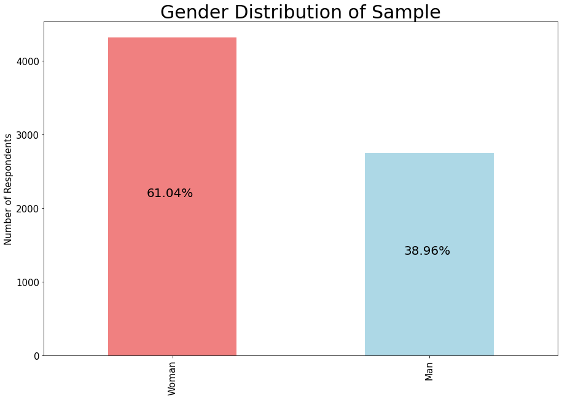

```python
ax = demdf['gender'].value_counts().plot(kind='bar', figsize=(15,10),
                                                  color=["lightcoral","lightblue"], fontsize=15);
ax.set_alpha(0.8)
ax.set_title("Gender Distribution of Sample", fontsize=30)
ax.set_ylabel('Number of Respondents',fontsize= 15)

totals = []

for i in ax.patches:
    totals.append(i.get_height())

total = sum(totals)

for i in ax.patches:
    ax.text(i.get_x()+.15, i.get_height()/2, str(round((i.get_height()/total)*100, 2))+'%',
            fontsize=20, color='black')
```

##### **Race**

- 85.59% Black/African
- 8.66% Coloured
- 4.6% White
- 1.12% Asian/Indian
- 0.03% Other

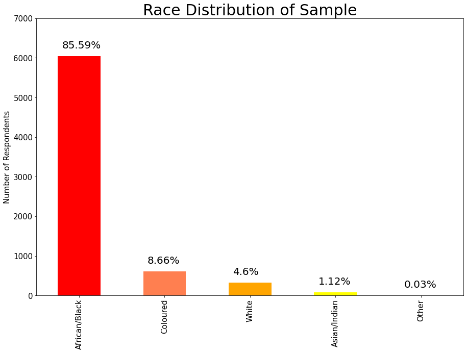

```python
ax = demdf['race'].value_counts().plot(kind='bar', figsize=(15,10),
                                       color=["red","coral","orange","yellow"], fontsize=15)

ax.set_alpha(0.8)
ax.set_title("Race Distribution of Sample", fontsize=30)
ax.set_ylabel('Number of Respondents',fontsize= 15)
ax.set_yticks([0, 1000, 2000, 3000, 4000, 5000,6000, 7000])


totals = []

for i in ax.patches:
    totals.append(i.get_height())

total = sum(totals)

for i in ax.patches:
    ax.text(i.get_x()+0.05, i.get_height()+200, str(round((i.get_height()/total)*100, 2))+'%',
            fontsize=20, color='black')
```

#### *Educational Information*

##### **Highest Education Level**

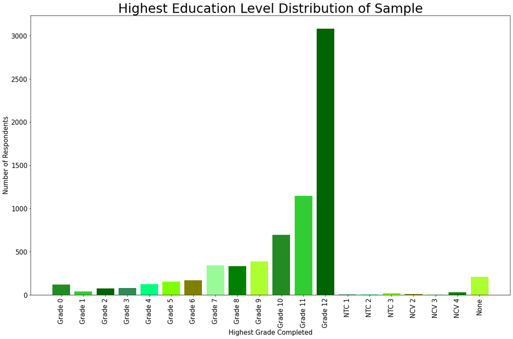

```python
grades = demdf['highest_grade'].value_counts()
ordered_grades = grades.reindex(index = ['Grade 0', 'Grade 1', 'Grade 2', 'Grade 3', 'Grade 4','Grade 5',
       'Grade 6', 'Grade 7', 'Grade 8', 'Grade 9', 'Grade 10',
       'Grade 11', 'Grade 12' , 'NTC 1', 'NTC 2', 'NTC 3', 'NCV 2','NCV 3','NCV 4', 'None'])

# my_cmap = cm.get_cmap('YlOrRd')

plt.figure(figsize=(20,12))

plt.bar(x = ordered_grades.index, height = ordered_grades.values,
        color=["forestgreen","limegreen","darkgreen","seagreen","springgreen","chartreuse","olive","palegreen","green","greenyellow"])

# plt.bar(x = ordered_grades.index, height = ordered_grades.values, color=my_cmap(ordered_grades.values))
plt.title('Highest Education Level Distribution of Sample',fontsize=30)
plt.xlabel('Highest Grade Completed',fontsize=15)
plt.ylabel('Number of Respondents',fontsize=15)
plt.xticks(rotation='vertical',fontsize=15)
plt.yticks(rotation='horizontal',fontsize=15)
plt.show()
```

##### **Tertiary Education**

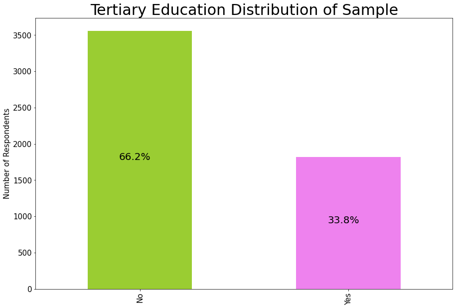

```python
ax = demdf['tertiary_edu'].value_counts().plot(kind='bar', figsize=(15,10),
                                                  color=["yellowgreen","violet"], fontsize=15);
ax.set_alpha(0.8)
ax.set_title("Tertiary Education Distribution of Sample", fontsize=30)
ax.set_ylabel('Number of Respondents',fontsize= 15)

totals = []

for i in ax.patches:
    totals.append(i.get_height())

total = sum(totals)

for i in ax.patches:
    ax.text(i.get_x()+.15, i.get_height()/2, str(round((i.get_height()/total)*100, 2))+'%',
            fontsize=20, color='black')
```

#### *Geographical Information*

In 2019, the total population was 58 775 022, with:

- Gauteng: 15 176 116 (25.8%)
- KwaZulu-Natal: 11 289 086 (19.2%)
- Western Cape: 6 844 272 (11.6%)
- Eastern Cape: 6 712 276 (11.4%)
- Limpopo: 5 982 584 (10.2%)
- Mpumalanga: 4 592 187 (7.8%)
- North West: 4 027 160 (6.9%)
- Free State: 2 887 465 (4.9%)
- Northern Cape: 1 263 875 (2.2%)

- Gauteng: 27.03%
- KwaZulu-Natal: 21.35%
- Limpopo: 10.81%
- Eastern Cape: 10.27%
- Mpumalanga: 9.73%
- Northern Cape: 6.22%
- Western Cape: 5.68%
- North West: 4.05%
- Free State: 4.59%

##### **Province Before Lockdown**

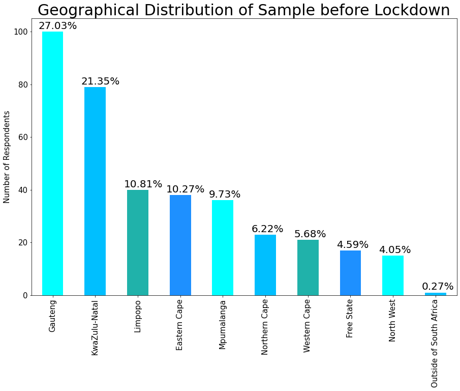

```python
ax = demdf['province_before'].value_counts().plot(kind='bar', figsize=(15,10),
                                       color=["aqua","deepskyblue","lightseagreen","dodgerblue"], fontsize=15)
ax.set_alpha(0.8)
ax.set_title("Geographical Distribution of Sample before Lockdown", fontsize=30)
ax.set_ylabel('Number of Respondents',fontsize= 15)

totals = []

for i in ax.patches:
    totals.append(i.get_height())

total = sum(totals)

for i in ax.patches:
    ax.text(i.get_x()-0.08, i.get_height()+1, str(round((i.get_height()/total)*100, 2))+'%',
            fontsize=20, color='black')
```

##### **Province During Lockdown**

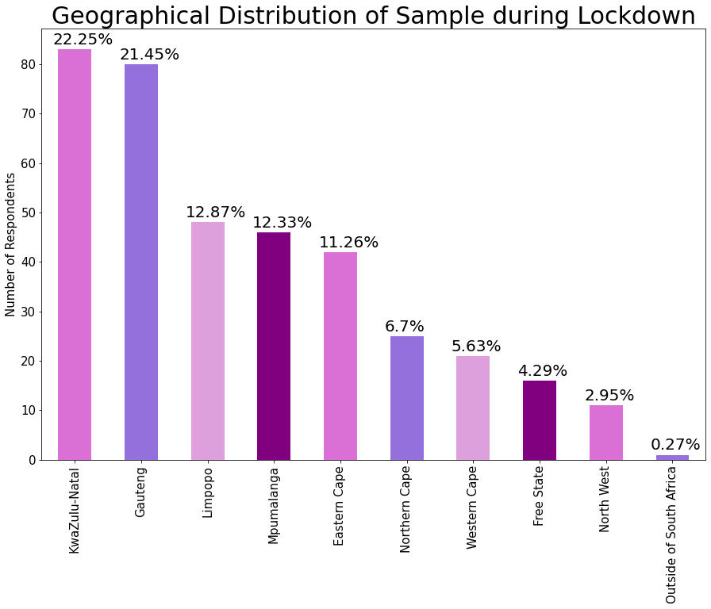

```python
ax = demdf['province_during'].value_counts().plot(kind='bar', figsize=(15,10),
                                       color=["orchid","mediumpurple","plum","purple"], fontsize=15);
ax.set_alpha(0.8)
ax.set_title("Geographical Distribution of Sample during Lockdown", fontsize=30)
ax.set_ylabel('Number of Respondents',fontsize= 15)

totals = []

for i in ax.patches:
    totals.append(i.get_height())

total = sum(totals)

for i in ax.patches:
    ax.text(i.get_x()-0.08, i.get_height()+1, str(round((i.get_height()/total)*100, 2))+'%',
            fontsize=20, color='black')
```

## Section 2 - Labour

### Data Description

**Work in February**

- **job_in_feb** - Had any kind of job in February
- **work_in_feb** - Did work for profit/pay even just for an hour or a small amount in February
- **bus_in_feb** - Did any businesss, big or small, even just for an hour in February
- **work_days_feb** - Average number of days worked per week in February
- **work_hours_feb** - Average number of hours worked per day in February
- **take_home_pay_feb** - Amount of take-home profit/pay in the month of February

**Work in April**

- **job_in_apr** - Had any kind of job in April
- **work_in_apr** - Did work for profit/pay even just for an hour or a small amount in April
- **bus_in_apr** - Did any businesss, big or small, even just for an hour in April
- **work_days_apr** - Average number of days worked per week in April
- **work_hours_apr** - Average number of hours worked per day in April
- **take_home_pay_apr** - Amount of take-home profit/pay in the month of April in April
- **return_to_work** - Have any paid activity/job to return to in the next 4 weeks (At time of survey) in April

**Type of work**

- **usual_work** - Occupational code for usual work

### Data Ingestion

First we will create a DataFrame which will contain a subset of relevant columns used for the Data Cleaning and Exploratory Data Analysis of the Labour features.

```python
lbdf = pd.DataFrame()

lbdf['job_in_feb'] = raw_data.w1_nc_em_feb
lbdf['work_in_feb'] = raw_data.w1_nc_emany_feb
lbdf['bus_in_feb'] = raw_data.w1_nc_ems_feb
lbdf['work_days_feb'] = raw_data.w1_nc_emdays_feb
lbdf['work_hours_feb'] = raw_data.w1_nc_emhrs_feb
lbdf['take_home_pay_feb'] = raw_data.w1_nc_eminc_feb

lbdf['job_in_apr'] = raw_data.w1_nc_em_apr
lbdf['work_in_apr'] = raw_data.w1_nc_emany_apr
lbdf['bus_in_apr'] = raw_data.w1_nc_ems_apr
lbdf['work_days_apr'] = raw_data.w1_nc_emdays_apr
lbdf['work_hours_apr'] = raw_data.w1_nc_emhrs_apr
lbdf['take_home_pay_apr'] = raw_data.w1_nc_eminc_apr
lbdf['return_to_work'] = raw_data.w1_nc_emreturn

lbdf['main_form_work'] = raw_data.w1_nc_emtyp
lbdf['usual_work'] = raw_data.w1_nc_emwrk_isco_c
```

Let us get a general feel for the data by taking a look at a sample of the data and by exploring some of the information about the data:

```python
lbdf.head()
```

|  | job_in_feb | work_in_feb | bus_in_feb | work_days_feb | work_hours_feb | take_home_pay_feb | job_in_apr | work_in_apr | bus_in_apr | work_days_apr | work_hours_apr | take_home_pay_apr | return_to_work | main_form_work | usual_work |
| --- | --- | --- | --- | --- | --- | --- | --- | --- | --- | --- | --- | --- | --- | --- | --- |
| 0 | Yes | NaN | NaN | NaN | NaN | 180.0 | No | No | No - I did nothing | NaN | NaN | NaN | NaN | NaN | NaN |
| 1 | No, I'm retired | NaN | NaN | NaN | NaN | NaN | NaN | NaN | NaN | NaN | NaN | NaN | NaN | NaN | NaN |
| 2 | No | No | No - I did nothing | NaN | NaN | NaN | No | No | No - I did nothing | NaN | NaN | NaN | No | NaN | NaN |
| 3 | Yes | NaN | NaN | 3.0 | 5.0 | 900.0 | No | No | No - I did nothing | 5.0 | 5.0 | NaN | Yes | Regular job | Elementary occupations |
| 4 | No | No | No - I did nothing | NaN | NaN | NaN | No | No | No - I did nothing | NaN | NaN | NaN | No | NaN | NaN |

```python
lbdf.info()
```

```
<class 'pandas.core.frame.DataFrame'>
RangeIndex: 7073 entries, 0 to 7072
Data columns (total 15 columns):
 #   Column             Non-Null Count  Dtype
---  ------             --------------  -----
 0   job_in_feb         6997 non-null   object
 1   work_in_feb        3684 non-null   object
 2   bus_in_feb         3356 non-null   object
 3   work_days_feb      3168 non-null   object
 4   work_hours_feb     3018 non-null   object
 5   take_home_pay_feb  2653 non-null   object
 6   job_in_apr         6329 non-null   object
 7   work_in_apr        4833 non-null   object
 8   bus_in_apr         4652 non-null   object
 9   work_days_apr      2142 non-null   object
 10  work_hours_apr     1790 non-null   object
 11  take_home_pay_apr  1402 non-null   object
 12  return_to_work     3977 non-null   object
 13  main_form_work     2602 non-null   object
 14  usual_work         2313 non-null   object
dtypes: object(15)
memory usage: 829.0+ KB
```

As we can see our dataset seems to contain a lot of missing data, let us see if through Data Preprocessing we can either impute or discard this missing data.

### Data Preprocessing

#### Feature Generation

To begin the data preprocessing we will first create new features using other features in our dataset. The first of these generated features are **labour_in_feb** and **labour_in_apr** this feature is created by checking if an individual had a job, did any part-time work or did any business in each of the months. This is done using the **check_labour** function below:

```python
def check_labour(jobfeb, workfeb, busfeb):
    if jobfeb == "Yes" or workfeb == "Yes" or busfeb =="Yes":
        return 1
    else:
        return 0

lbdf['labour_in_feb'] = np.vectorize(check_labour)(lbdf['job_in_feb'],lbdf['work_in_feb'],lbdf['bus_in_feb'])
lbdf['labour_in_apr'] = np.vectorize(check_labour)(lbdf['job_in_apr'],lbdf['work_in_apr'],lbdf['bus_in_apr'])
```

Now that we have created these new features which are good indications of whether or not a respondent was making any money through labour in February and April we can drop the less useful and now somewhat redundance job, work and business features for each month.

```python
lbdf = lbdf.drop(['job_in_feb','work_in_feb','bus_in_feb','job_in_apr','work_in_apr','bus_in_apr'] , axis = 1)
```

The second feature we can create is **lost_labour** which will check if a respondent who was working in February had lost their opportunity to work by April.

```python
def lost_labour(labour_in_feb,labour_in_apr):
    if labour_in_feb == 1 and labour_in_apr ==0:
        return 1
    else:
        return 0

lbdf['lost_labour'] = np.vectorize(lost_labour)(lbdf['labour_in_feb'],lbdf['labour_in_apr'])
```

With these two new features created, let us rerrange our columns into a more logical order and re-examine how a sample from our data will now look.

```python
list_of_col_names = ['labour_in_feb','work_days_feb', 'work_hours_feb', 'take_home_pay_feb', 'labour_in_apr', 'work_days_apr',
       'work_hours_apr', 'take_home_pay_apr', 'lost_labour', 'return_to_work',
       'main_form_work', 'usual_work']

lbdf = lbdf.filter(list_of_col_names)
lbdf.head()
```

|  | labour_in_feb | work_days_feb | work_hours_feb | take_home_pay_feb | labour_in_apr | work_days_apr | work_hours_apr | take_home_pay_apr | lost_labour | return_to_work | main_form_work | usual_work |
| --- | --- | --- | --- | --- | --- | --- | --- | --- | --- | --- | --- | --- |
| 0 | 1 | NaN | NaN | 180.0 | 0 | NaN | NaN | NaN | 1 | NaN | NaN | NaN |
| 1 | 0 | NaN | NaN | NaN | 0 | NaN | NaN | NaN | 0 | NaN | NaN | NaN |
| 2 | 0 | NaN | NaN | NaN | 0 | NaN | NaN | NaN | 0 | No | NaN | NaN |
| 3 | 1 | 3.0 | 5.0 | 900.0 | 0 | 5.0 | 5.0 | NaN | 1 | Yes | Regular job | Elementary occupations |
| 4 | 0 | NaN | NaN | NaN | 0 | NaN | NaN | NaN | 0 | No | NaN | NaN |

#### Missing Data

The next step in the data preprocessing is to deal with the missing data. Is it important to note that the original dataset contains some sentinel values such as "Missing" which will have to be replaced with NaN to be treated correctly in the cleaning process. Similarly, in cases where a respondent refused to answer or answered "Don't know" these entries will also have to be replaced with NaN values as this data is missing. The function **replace_errors** below is a generalized function which will allow us to replace these erroneous entries with missing values.

```python
def replace_errors(x):
    if x == "Don't know" or x == "Refused" or x=='Missing' or x== "Don't Know" or x=="Donât know" or x== "I was on leave" or x == "Other":
        return np.NaN
    return x

#Apply the replace_errors function to each column in our DataFrame
for column in lbdf.columns:
    lbdf[column] = lbdf[column].apply(replace_errors)
```

An important caveat to note is that if a respondent did not have any work in February then the number of days they worked per week, the number of hours they worked per dat and their take home pay will all be 0. Similarly, if a respondent did not have any work in April, their days worked, hours worked and take home pay will also be 0.

```python
lbdf.loc[lbdf['labour_in_feb']==0 ,['work_days_feb','work_hours_feb','take_home_pay_feb']] = 0
lbdf.loc[lbdf['labour_in_apr']==0,['work_days_apr','work_hours_apr','take_home_pay_apr']] = 0
```

Let us take a look at what percentage of data is missing for each feature in our DataFrame

```python
print('Percentage of Data Missing')
display(round((lbdf.isnull().sum()/len(lbdf))*100,2))
```

```
Percentage of Data Missing
```

```
labour_in_feb         0.00
work_days_feb         2.47
work_hours_feb        4.17
take_home_pay_feb     9.52
labour_in_apr         0.00
work_days_apr         5.77
work_hours_apr        6.45
take_home_pay_apr    11.65
lost_labour           0.00
return_to_work       43.77
main_form_work       63.21
usual_work           67.30
dtype: float64
```

As we can see the features for the work days per week, work hours per day and take home pay features for both February and April are all missing less than 12% of their values. First we need to ensure these features are the correct data type, next we can impute these values by first identifying which respondents actually had labour in that month and then calculating the mean of that feauture and replacing the missing data with that mean. Because answers for work days and work hours were discrete we will have to round the calculated mean to the nearest discrete integer.

```python
#Ensure correct data type
lbdf.loc[:,'work_days_feb'] = pd.to_numeric(lbdf['work_days_feb'])

#Locate the respondents who had some sort of labour in February month and calculate the mean of their work days
avg_work_day_feb = np.mean(lbdf.loc[lbdf['labour_in_feb']==1,'work_days_feb'])

#Replace the missing work day values for people who had labour in February with the discretized calculated mean
lbdf.loc[(lbdf['labour_in_feb']==1)&(lbdf['work_days_feb'].isnull()),'work_days_feb'] = round(avg_work_day_feb,0)

#Repeat the same process for the other relevant features
lbdf.loc[:,'work_hours_feb'] = pd.to_numeric(lbdf['work_hours_feb'])
avg_work_hours_feb = np.mean(lbdf.loc[lbdf['labour_in_feb']==1,'work_hours_feb'])
lbdf.loc[(lbdf['labour_in_feb']==1)&(lbdf['work_hours_feb'].isnull()),'work_hours_feb'] = round(avg_work_hours_feb,0)

#Here we do not discretize the mean as this is a continous feature
lbdf.loc[:,'take_home_pay_feb'] = pd.to_numeric(lbdf['take_home_pay_feb'])
avg_take_home_pay_feb = np.mean(lbdf.loc[lbdf['labour_in_feb']==1,'take_home_pay_feb'])
lbdf.loc[(lbdf['labour_in_feb']==1)&(lbdf['take_home_pay_feb'].isnull()),'take_home_pay_feb'] = avg_take_home_pay_feb

lbdf.loc[:,'work_days_apr'] = pd.to_numeric(lbdf['work_days_apr'])
avg_work_day_apr = np.mean(lbdf.loc[lbdf['labour_in_apr']==1,'work_days_apr'])
lbdf.loc[(lbdf['labour_in_apr']==1)&(lbdf['work_days_apr'].isnull()),'work_days_apr'] = round(avg_work_day_apr,0)

lbdf.loc[:,'work_hours_apr'] = pd.to_numeric(lbdf['work_hours_apr'])
avg_work_hours_apr = np.mean(lbdf.loc[lbdf['labour_in_apr']==1,'work_hours_apr'])
lbdf.loc[(lbdf['labour_in_apr']==1)&(lbdf['work_hours_apr'].isnull()),'work_hours_apr'] = round(avg_work_hours_apr,0)

lbdf.loc[:,'take_home_pay_apr'] = pd.to_numeric(lbdf['take_home_pay_apr'])
avg_take_home_pay_apr = np.mean(lbdf.loc[lbdf['labour_in_apr']==1,'take_home_pay_apr'])
lbdf.loc[(lbdf['labour_in_apr']==1)&(lbdf['take_home_pay_apr'].isnull()),'take_home_pay_apr'] = avg_take_home_pay_apr
```

Next we need to determine a way to impute the values for return_to_work because, as can be seen above, about 43.77% of our entries are missing values for this feature. This feature indicates whether or not the respondent will have work to return to in the 4 weeks following the interviews (which were conducted just after April). To impute the missing value, we make the assumption that someone who has work at the time of the interview will still have work in 4 weeks whilst people who had lost their work may or may not be able to return to work. The function **check_return** allows us to simultaneously perform these checks and use binary encoding to encode this feature.

```python
def check_return(labour_in_apr,  return_to_work):
    if labour_in_apr == 1:
        return 1
    else:
        if return_to_work=='Yes':
            return 1
    return 0
```

```python
lbdf.loc[:,'return_to_work'] = np.vectorize(check_return)(lbdf['labour_in_apr'], lbdf['return_to_work'])
```

Next, we will try to impute values for the usual_work feature. Let us first examine what are some possible answers to this question.

```python
lbdf['usual_work'].value_counts()
```

```
Elementary occupations                                551
Service and sales workers                             412
Professionals                                         315
Clerical support workers                              246
Craft and related trades workers                      193
Plant and machine operators, and assemblers           182
Technicians and associate professionals               169
Managers                                              100
Not Employed                                           81
Skilled agricultural, forestry and fishery workers     39
Self-Employed                                          13
Not applicable                                         10
Armed forces occupations                                2
Name: usual_work, dtype: int64
```

We can see that there is an option for "Not Employed". We can leverage the fact that we know the work-status of our respondents before COVID-19 (stored in lavour_in_feb) so we can assign these respondents with 'Not Employed' for their usual work.

```python
lbdf.loc[lbdf['labour_in_feb']==0,'usual_work'] = 'Not Employed'
```

Next, by examining the possible options for the main_form_work feature we can see that several repsondents answered "Self-employed" or "I run a business"

```python
lbdf['main_form_work'].value_counts()
```

```
Regular job         1581
Casual work          628
Self-employed        307
I run a business      86
Name: main_form_work, dtype: int64
```

Below we can see that some respondents who answered the main_form_work question have missing values for usual_work.

```python
lbdf.loc[lbdf['main_form_work'].notnull(),['main_form_work','usual_work']].tail()
```

|  | main_form_work | usual_work |
| --- | --- | --- |
| 7049 | Regular job | Not Employed |
| 7050 | Casual work | Elementary occupations |
| 7052 | I run a business | NaN |
| 7059 | Regular job | Not Employed |
| 7066 | Regular job | Not Employed |

We can use our prior knowledge to deduce that if they answered 'Self-employed' or 'I run a business' for main_form_work that their usual_work can be set as "Self-Employed". We can also frop main_form_work as it has now become a less useful and somewhat redundant feature.

```python
lbdf.loc[(lbdf['main_form_work']=='Self-employed')|(lbdf['main_form_work']=='I run a business'),'usual_work']= 'Self-Employed'
lbdf.drop('main_form_work', axis=1, inplace=True)
```

For the remaining missing values we will create a new option for usual_work called 'Unknown'.

```python
lbdf.loc[lbdf['usual_work'].isnull(), 'usual_work'] = 'Unknown'
```

After our data cleaning process, we can see that there is no longer any missing data.

```python
print('Percentage of Data Missing after Data Cleaning')
display(round((lbdf.isnull().sum()/len(lbdf))*100,2))
```

```
Percentage of Data Missing after Data Cleaning
```

```
labour_in_feb        0.0
work_days_feb        0.0
work_hours_feb       0.0
take_home_pay_feb    0.0
labour_in_apr        0.0
work_days_apr        0.0
work_hours_apr       0.0
take_home_pay_apr    0.0
lost_labour          0.0
return_to_work       0.0
usual_work           0.0
dtype: float64
```